# Analyse crédits de recherche

# Rappel du projet

## Méthode

Des enregistreurs ont été placés sur 26 étangs de reproductions d’anoures et ils ont été opérationnels du 5 mai 2021 au 13 juillet 2021 et du 19 avril 2022 au 27 juillet 2022. Des enregistrements de 3 minutes ont eu lieux à 15h, à 21h et à 1h à chaque semaine. Chaque enregistrement a été écouté et pour chacun j’ai noté le site, la date, l’heure, la qualité de l’enregistrement, la principale perturbation sonore ainsi que la présence ou absence de chaque espèce.

Autour de chaque site, une zone tampon d’un rayon de 300 m a été délimitée puisque c’est la distance moyenne parcourue par les anoures. Sur QGIS, j’ai utilisé les couches gouvernementales d’utilisation du territoire, de réseau routier et de milieux humides potentiels pour obtenir les superficies de recouvrement des différents types de milieux.

## Objectifs

- Évaluer les relations entre les variables environnementales et la probabilité d’occupation des espèces d’anoures dans différents étangs de reproduction.
- Déterminer quelle variable ou quel ensemble de variables environnementales influence le plus la probabilité d’occupation de chaque espèce d’anoure

## Hypothèses

Je n’ai pas pu aller sur le terrain finalement et peu de variables pouvaient être utilisées pour les différents modèles alors j’ai du changer mes hypothèses. De plus, j’ai du utiliser la présence au lieu de l’abondance dans les modèles statistiques. Voici mes hypothèses modifiées compte tenu des restrictions :

- 1.1 La présence de milieux humides en périphérie des étangs de reproduction augmente la présence d’anoures
- 1.2 Les milieux humides avec de l’eau permanente favorisent la présence d’anoures avec un long stade larvaire puisque les larves de certaines espèces doivent rester jusqu’à deux saisons dans l’eau avant la métamorphose.
- 1.3 La présence de site agricoles en périphérie des étangs de reproduction réduit la présence d’anoures
- 1.4 la présence de routes en périphérie des étangs réduit l’abondance d’anoures puisqu’elles sont une cause de mortalité importante

# Analyse statistique

L’analyse statistique est faite à partir du package `unmarked` et `AICcmodavg`

Les modèles prennent en compte la **probabilité de détection**, qui varie selon les conditions de l’échantillonnage, et la **probabilité d’occupation**, qui varie selon les caractéristiques du site et du paysage.

## Variable réponse (présence ou absence)

Les deux seules espèces ayant un nombre d’observation suffisant et qui n’étaient pas présentes dans tous les sites sont la **grenouille des bois** et le **ouaouaron**. Ce sont donc les deux espèces utilisées dans l’analyse

### Grenouille des bois

Les données sont celles de 2022 seulement puisqu’il n’y a aucune observation en 2021 (les enregistrements ont commencé trop tard). Les observations de l’espèce ont eu lieu à 21h et à 1h.

Nombre d’observations: 25

Nombre de sites où l’espèce est observée : 11

```r
str(lisyl)
```

```
## 'data.frame':    26 obs. of  4 variables:
##  $ V1: int  0 0 1 0 0 0 0 NA 0 0 ...
##  $ V2: int  0 0 0 0 0 0 0 NA 0 0 ...
##  $ V3: int  0 0 1 0 0 0 0 0 1 0 ...
##  $ V4: int  0 0 1 0 0 0 0 0 1 0 ...
```

### Ouaouaron

Les observations sont à 1 h en 2021 et 2022. Les visites à 15 h et 21 h n’ont pas été utilisées puisqu’il n’y avait qu’une à trois observations

Nombre d’observations 2021: 43

Nombre d’observations 2022: 32

Nombre de sites où l’espèce est observée 2021: 14

Nombre de sites où l’espèce est observée 2022: 15

Dates de visites (quand l’espèce est active) 2021: 27 mai au 7 juillet

Dates de visites (quand l’espèce est active) 2022: 25 mai au 20 juillet

```r
str(licat)
```

```
## 'data.frame':    52 obs. of  9 variables:
##  $ V1: int  0 0 0 0 0 0 NA 0 0 0 ...
##  $ V2: int  0 0 0 0 0 0 1 0 1 0 ...
##  $ V3: int  0 0 0 0 0 0 0 0 0 0 ...
##  $ V4: int  0 0 0 0 0 0 0 0 0 0 ...
##  $ V5: int  0 0 0 0 0 0 1 0 0 0 ...
##  $ V6: int  0 0 0 0 0 0 1 0 1 1 ...
##  $ V7: int  0 0 0 0 0 0 1 0 0 0 ...
##  $ V8: int  NA NA NA NA NA NA NA NA NA NA ...
##  $ V9: int  NA NA NA NA NA NA NA NA NA NA ...
```

Les visites de 2022 ont été ajoutées sous celles de 2021. Donc pour chaque visite (V), il y a les enregistrements de 2021 et de 2022. Puisque l’espèce était active moins longtemps en 2021, il y a des NAs dans le tableau aux visites V8 et V9.

## Variables de détection

- **Types de Perturbation** : Human, meteo ou none
- **Qualité de l’enregistrement** : Good, moderate ou bad
- **Heure de l’enregistrement** (pour la grenouilles des bois seulement): 21h ou 1h
- **Année de l’enregistrement** (pour le ouaouaron seulement) : 2021 ou 2022
- **Jour de l’enregistrement**: en jour julien

Exemple : Tableau des jours juliens pour la grenouille des bois

```r
str(jj_lisyl)
```

```
## 'data.frame':    26 obs. of  4 variables:
##  $ V1: int  108 108 109 109 109 109 111 NA 109 109 ...
##  $ V2: int  109 109 110 110 110 110 112 NA 110 110 ...
##  $ V3: int  115 115 115 115 115 115 115 116 115 115 ...
##  $ V4: int  116 116 116 116 116 116 116 117 116 116 ...
```

Exemple : Tableau de l’année (transformé en facteur) pour le ouaouaron

```r
str(annee_licat)
```

```
## 'data.frame':    52 obs. of  9 variables:
##  $ V1: Factor w/ 2 levels "2021","2022": 1 1 1 1 1 1 NA 1 1 1 ...
##  $ V2: Factor w/ 2 levels "2021","2022": 1 1 1 1 1 1 1 1 1 1 ...
##  $ V3: Factor w/ 2 levels "2021","2022": 1 1 1 1 1 1 1 1 1 1 ...
##  $ V4: Factor w/ 2 levels "2021","2022": 1 1 1 1 1 1 1 1 1 1 ...
##  $ V5: Factor w/ 2 levels "2021","2022": 1 1 1 1 1 1 1 1 1 1 ...
##  $ V6: Factor w/ 2 levels "2021","2022": 1 1 1 1 1 1 1 1 1 1 ...
##  $ V7: Factor w/ 2 levels "2021","2022": 1 1 1 1 1 1 1 1 1 1 ...
##  $ V8: Factor w/ 2 levels "2021","2022": NA NA NA NA NA NA NA NA NA NA ...
##  $ V9: Factor w/ 2 levels "2021","2022": NA NA NA NA NA NA NA NA NA NA ...
```

### Corrélation des variables

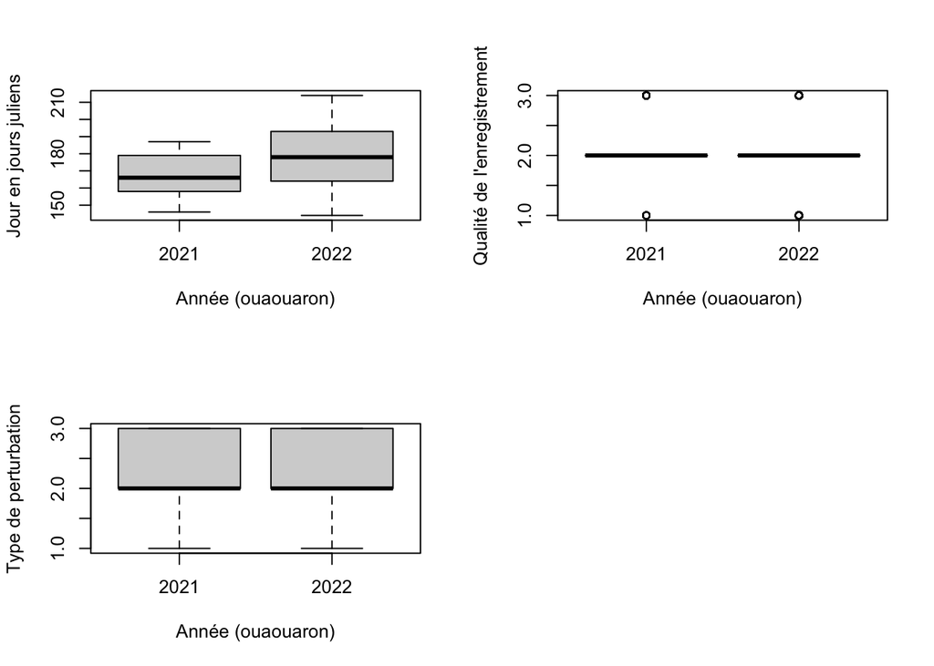

```r
par(mfrow=c(2,2))
boxplot(anoure_licat$jour_julien ~ anoure_licat$Year, xlab = 'Année (ouaouaron)', ylab = "Jour en jours juliens")
boxplot(anoure_licat$RecordingQuality ~ anoure_licat$Year, xlab = 'Année (ouaouaron)', ylab = "Qualité de l'enregistrement")
boxplot(anoure_licat$DisturbanceType ~ anoure_licat$Year, xlab = 'Année (ouaouaron)', ylab = "Type de perturbation")
```

La qualité d’enregistrement et le type de perturbation ne varient pas avec l’année alors on peut faire les modèles jumelant ces variables

Le jour varie entre les années alors il ne faut pas les laisser ensemble dans les modèles

```r
table(anoure$RecordingQuality, anoure$DisturbanceType)
```

```
##
##            human meteo none
##   bad          6   225    0
##   good       128    47  274
##   moderate   557   568    0
```

## Variables d’occupation

Obtenues à partir de couches qgis

- **Milieux humide** : Superficie (m2) des milieux humides de type Milieu humide, Tourbières et Marécage
- **Eau libre** : Superficie (m2) des milieux humides de type Marais, Lac, Eau peu profonde et Eau
- **Route** : Nombre de km de route total
- **Agriculture** : Superficie (m2) de tous les types d’agriculture
- **Site** : Facteur ; lisière de forêt ou en forêt
- **Annéee** : Pour le ouaouaron seulement puisque les données sont sur deux années. Facteur entre 2021 et 2022

Les superficies ont été transformées en pourcentage de recouvrement puis standardisées avec la fonction `scale()`

```r
str(occupation_lisyl)
```

```
## 'data.frame':    26 obs. of  6 variables:
##  $ Enregistre : chr  "C-foret" "C-lisiere" "E-foret" "E-lisiere" ...
##  $ Route      : num [1:26, 1] -0.528 1.254 -0.528 1.192 -0.528 ...
##   ..- attr(*, "scaled:center")= num 161
##   ..- attr(*, "scaled:scale")= num 305
##  $ Agriculture: num [1:26, 1] -0.895 0.483 -1.344 -1.213 -1.369 ...
##   ..- attr(*, "scaled:center")= num 0.164
##   ..- attr(*, "scaled:scale")= num 0.12
##  $ Eau        : num [1:26, 1] -0.502 -0.502 -0.502 -0.502 1.462 ...
##   ..- attr(*, "scaled:center")= num 0.0539
##   ..- attr(*, "scaled:scale")= num 0.107
##  $ Humide     : num [1:26, 1] 0.798 0.321 1.033 0.675 0.625 ...
##   ..- attr(*, "scaled:center")= num 0.685
##   ..- attr(*, "scaled:scale")= num 0.304
##  $ Site       : Factor w/ 2 levels "foret","lisiere": 1 2 1 2 1 2 2 1 2 2 ...
```

```r
str(occupation_licat)
```

```
## 'data.frame':    52 obs. of  7 variables:
##  $ Enregistre : chr  "C-foret" "C-lisiere" "E-foret" "E-lisiere" ...
##  $ Route      : num [1:52, 1] -0.534 1.266 -0.534 1.204 -0.534 ...
##   ..- attr(*, "scaled:center")= num 161
##   ..- attr(*, "scaled:scale")= num 302
##  $ Agriculture: num [1:52, 1] -0.904 0.488 -1.358 -1.225 -1.382 ...
##   ..- attr(*, "scaled:center")= num 0.164
##   ..- attr(*, "scaled:scale")= num 0.119
##  $ Eau        : num [1:52, 1] -0.507 -0.507 -0.507 -0.507 1.477 ...
##   ..- attr(*, "scaled:center")= num 0.0539
##   ..- attr(*, "scaled:scale")= num 0.106
##  $ Humide     : num [1:52, 1] 0.806 0.324 1.044 0.682 0.631 ...
##   ..- attr(*, "scaled:center")= num 0.685
##   ..- attr(*, "scaled:scale")= num 0.301
##  $ Site       : Factor w/ 2 levels "foret","lisiere": 1 2 1 2 1 2 2 1 2 2 ...
##  $ annee      : Factor w/ 2 levels "2021","2022": 1 1 1 1 1 1 1 1 1 1 ...
```

### Corrélation des variables

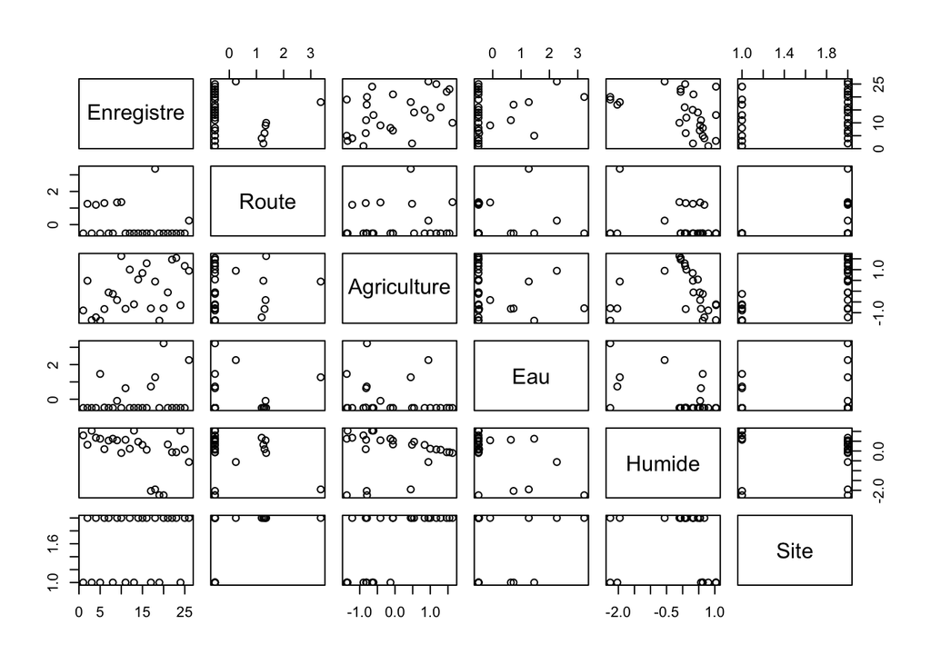

```r
plot(occupation_lisyl)
```

## Création des modèles pour la grenouille des bois

Création de la base de données pour le package `unmarked`

```r
lisyl.data <- unmarkedFrameOccu(y = lisyl, siteCovs = occupation_lisyl, obsCovs = list(disturbance = perturb_lisyl, qualite = qualite_lisyl, heure = heure_lisyl, jour = jj_lisyl))
summary(lisyl.data)
```

```
## unmarkedFrame Object
##
## 26 sites
## Maximum number of observations per site: 4
## Mean number of observations per site: 3.92
## Sites with at least one detection: 11
##
## Tabulation of y observations:
##    0    1 <NA>
##   77   25    2
##
## Site-level covariates:
##      Enregistre      Route.V1         Agriculture.V1          Eau.V1
##  C-foret  : 1   Min.   :-0.52849   Min.   :-1.3686004   Min.   :-0.501616
##  C-lisiere: 1   1st Qu.:-0.52849   1st Qu.:-0.8155866   1st Qu.:-0.501616
##  E-foret  : 1   Median :-0.52849   Median :-0.0946828   Median :-0.501616
##  E-lisiere: 1   Mean   : 0.00000   Mean   : 0.0000000   Mean   : 0.000000
##  F-foret  : 1   3rd Qu.: 0.04769   3rd Qu.: 0.9192348   3rd Qu.:-0.188291
##  F-lisiere: 1   Max.   : 3.36727   Max.   : 1.6292200   Max.   : 3.227821
##  (Other)  :20
##       Humide.V1            Site
##  Min.   :-2.2519242   foret  : 9
##  1st Qu.:-0.0623993   lisiere:17
##  Median : 0.3163799
##  Mean   : 0.0000000
##  3rd Qu.: 0.6111054
##  Max.   : 1.0376999
##
##
## Observation-level covariates:
##  disturbance     qualite    heure         jour
##  human:29    bad     : 4   1   :51   Min.   :108.0
##  meteo:21    good    :66   21  :51   1st Qu.:111.0
##  none :52    moderate:32   NA's: 2   Median :115.0
##  NA's : 2    NA's    : 2             Mean   :113.1
##                                      3rd Qu.:116.0
##                                      Max.   :117.0
##                                      NA's   :2
```

#### Modèles

```r
# Détectabilité et occupation constante (modèle nul)
mb0 <- occu(~ 1 ~ 1, data = lisyl.data)

# Détectabilité varie selon la qualité de l'enregistrement et l'occupation varie selon...
# Le pourcentage de recouvrement de milieux humides
mbQH <- occu(~ qualite ~ Humide, data = lisyl.data)
# Le pourcentage de recouvrement de milieux d'eau libre
mbQE <- occu(~ qualite ~ Eau, data = lisyl.data)
# Le nombre de km de routes
mbQR <- occu(~ qualite ~ Route, data = lisyl.data)
# Le pourcentage de recouvrement de terres agricoles
mbQA <- occu(~ qualite ~ Agriculture, data = lisyl.data)
# Le positionnement du site (en lisière ou en forêt)
mbQS <- occu(~ qualite ~ Site, data = lisyl.data)

# Détectabilité varie selon le type de perturbation et occupation varie selon ...
mbPH <- occu(~ disturbance ~ Humide, data = lisyl.data)
mbPE <- occu(~ disturbance ~ Eau, data = lisyl.data)
mbPR <- occu(~ disturbance ~ Route, data = lisyl.data)
mbPA <- occu(~ disturbance ~ Agriculture, data = lisyl.data)
mbPS <- occu(~ disturbance ~ Site, data = lisyl.data)

# Détectabilité varie selon l'heure et occupation varie selon ...
mbHH <- occu(~ heure ~ Humide, data = lisyl.data)
mbHE <- occu(~ heure ~ Eau, data = lisyl.data)
mbHR <- occu(~ heure ~ Route, data = lisyl.data)
mbHA <- occu(~ heure ~ Agriculture, data = lisyl.data)
mbHS <- occu(~ heure ~ Site, data = lisyl.data)

# Détectabilité varie selon les jours juliens et occupation varie selon ...
mbDH <- occu(~ jour ~ Humide, data = lisyl.data)
mbDE <- occu(~ jour ~ Eau, data = lisyl.data)
mbDR <- occu(~ jour ~ Route, data = lisyl.data)
mbDA <- occu(~ jour ~ Agriculture, data = lisyl.data)
mbDS <- occu(~ jour ~ Site, data = lisyl.data)
```

Tableau de tous les modèles avec le poid AIC

```r
# Liste des modèles
Cands <- list(mb0, mbQH, mbQE, mbQR, mbQA, mbQS, mbPH, mbPE, mbPR, mbPA, mbPS, mbHH, mbHE, mbHR, mbHA, mbHS, mbDH, mbDE, mbDR, mbDA, mbDS)

# Noms des modèles
Model.names <- c("nul","occupation(Milieux humides)détection(Qualité)", "occupation(Eau libre)détection(Qualité)", "occupation(Route)détection(Qualité)", "occupation(Agriculture)détection(Qualité)", "occupation(Site)détection(Qualité)", "occupation(Milieux humides)détection(Perturb)", "occupation(Eau libre)détection(Perturb)", "occupation(Route)détection(Perturb)", "occupation(Agriculture)détection(Perturb)", "occupation(Site)détection(Perturb)", "occupation(Milieux humides)détection(Heure)", "occupation(Eau libre)détection(Heure)", "occupation(Route)détection(Heure)", "occupation(Agriculture)détection(Heure)", "occupation(Site)détection(Heure)", "occupation(Milieux humides)détection(Jour)", "occupation(Eau libre)détection(Jour)", "occupation(Route)détection(Jour)", "occupation(Agriculture)détection(Jour)", "occupation(Site)détection(Jour)")

# Sélection des modèles basées sur AICc
aictab(cand.set = Cands,  modnames = Model.names)
```

```
##
## Model selection based on AICc:
##
##                                               K   AICc Delta_AICc AICcWt Cum.Wt
## occupation(Route)détection(Jour)              4  96.84       0.00   0.24   0.24
## occupation(Eau libre)détection(Jour)          4  98.53       1.69   0.10   0.34
## occupation(Route)détection(Heure)             4  99.00       2.16   0.08   0.42
## nul                                           2  99.01       2.17   0.08   0.50
## occupation(Route)détection(Qualité)           5  99.07       2.23   0.08   0.57
## occupation(Milieux humides)détection(Jour)    4  99.24       2.40   0.07   0.64
## occupation(Agriculture)détection(Jour)        4  99.41       2.57   0.07   0.71
## occupation(Site)détection(Jour)               4  99.87       3.02   0.05   0.76
## occupation(Eau libre)détection(Qualité)       5 100.61       3.77   0.04   0.80
## occupation(Eau libre)détection(Heure)         4 100.76       3.92   0.03   0.83
## occupation(Milieux humides)détection(Heure)   4 101.46       4.62   0.02   0.85
## occupation(Milieux humides)détection(Qualité) 5 101.64       4.79   0.02   0.88
## occupation(Route)détection(Perturb)           5 101.65       4.81   0.02   0.90
## occupation(Agriculture)détection(Heure)       4 101.69       4.85   0.02   0.92
## occupation(Agriculture)détection(Qualité)     5 101.72       4.88   0.02   0.94
## occupation(Site)détection(Qualité)            5 101.74       4.90   0.02   0.96
## occupation(Site)détection(Heure)              4 102.14       5.30   0.02   0.98
## occupation(Eau libre)détection(Perturb)       5 103.36       6.52   0.01   0.98
## occupation(Agriculture)détection(Perturb)     5 104.40       7.56   0.01   0.99
## occupation(Milieux humides)détection(Perturb) 5 104.41       7.57   0.01   1.00
## occupation(Site)détection(Perturb)            5 104.57       7.73   0.00   1.00
##                                                   LL
## occupation(Route)détection(Jour)              -43.47
## occupation(Eau libre)détection(Jour)          -44.32
## occupation(Route)détection(Heure)             -44.55
## nul                                           -47.25
## occupation(Route)détection(Qualité)           -43.04
## occupation(Milieux humides)détection(Jour)    -44.67
## occupation(Agriculture)détection(Jour)        -44.75
## occupation(Site)détection(Jour)               -44.98
## occupation(Eau libre)détection(Qualité)       -43.81
## occupation(Eau libre)détection(Heure)         -45.43
## occupation(Milieux humides)détection(Heure)   -45.78
## occupation(Milieux humides)détection(Qualité) -44.32
## occupation(Route)détection(Perturb)           -44.33
## occupation(Agriculture)détection(Heure)       -45.89
## occupation(Agriculture)détection(Qualité)     -44.36
## occupation(Site)détection(Qualité)            -44.37
## occupation(Site)détection(Heure)              -46.12
## occupation(Eau libre)détection(Perturb)       -45.18
## occupation(Agriculture)détection(Perturb)     -45.70
## occupation(Milieux humides)détection(Perturb) -45.70
## occupation(Site)détection(Perturb)            -45.78
```

L’AICc dépend de la vraisemblance (négative) et du nombre de paramètres (positivement). Il permet donc de trouver le/les modèle qui explique le mieux la variation des données. Un petit AIC est donc préféré.

Delta AICc est la différence entre le AICc du modèle et celui du meilleur modèle. On veut donc un DeltaAICc le plus petit (< 2)

Les modèles qui ont le plus de poids (AICcWt) (qui expliquent une plus grande proportion de la variation dans les variables réponses) sont ceux avec **Route** et **Jour**, suivi de **Eau libre** et **Jour**

```r
mbDR
```

```
##
## Call:
## occu(formula = ~jour ~ Route, data = lisyl.data)
##
## Occupancy:
##             Estimate    SE      z P(>|z|)
## (Intercept)   -0.342 0.470 -0.728   0.467
## Route         -0.945 0.656 -1.441   0.150
##
## Detection:
##             Estimate     SE     z P(>|z|)
## (Intercept)  -30.058 15.161 -1.98  0.0474
## jour           0.267  0.134  1.99  0.0465
##
## AIC: 94.93843
```

```r
mbDE
```

```
##
## Call:
## occu(formula = ~jour ~ Eau, data = lisyl.data)
##
## Occupancy:
##             Estimate    SE      z P(>|z|)
## (Intercept)   -0.263 0.435 -0.605   0.545
## Eau           -0.561 0.533 -1.051   0.293
##
## Detection:
##             Estimate     SE     z P(>|z|)
## (Intercept)  -30.038 15.088 -1.99  0.0465
## jour           0.267  0.133  2.00  0.0456
##
## AIC: 96.63001
```

La détection est influencée positivement par le jour de l’enregistrement (pente = 0,267 et p-value = 0.0465).

La relation entre l’occupation et la route ou l’eau libre n’est pas significative.

### Vérification ajustement du modèle

Code ajustement du modèle

```r
ajust <- mb.gof.test(mbDR, nsim = 5000, plot.hist=T)
save(ajust, file = "lisyl_ajust_gof.Rdata")
```

```r
load("lisyl_ajust_gof.Rdata")
ajust
```

```
##
## MacKenzie and Bailey goodness-of-fit for single-season occupancy model
##
## Pearson chi-square table:
##
##      Cohort Observed Expected Chi-square
## 0000      0       14    14.45       0.01
## 0010      0        2     0.79       1.84
## 0011      0        2     1.97       0.00
## 0111      0        1     1.33       0.08
## 1000      0        1     0.22       2.85
## 1001      0        1     0.54       0.40
## 1011      0        2     1.02       0.94
## 1110      0        1     0.32       1.41
## 1111      0        1     0.80       0.05
## ..00      1        1     0.50       0.51
##
## Chi-square statistic = 12.1584
## Number of bootstrap samples = 5000
## P-value = 0.6762
##
## Quantiles of bootstrapped statistics:
##   0%  25%  50%  75% 100%
##  1.4 11.3 14.5 18.5 70.1
##
## Estimate of c-hat = 0.79
```

Pas besoin de réajuster le modèle puisque le c-hat (0.79) est < à 1

### Inférence multimodèles

Avec l’utilisation du package `AICcmodavg`

Important parce que les meilleurs modèles n’ont pas tout le poids AIC. Permet de combiner les différents modèles selon leur poids AIC.

La seule variable ayant une influence significative sur la détection : **Jour**

```r
modavgShrink(cand.set = Cands, modnames = Model.names, parm = "jour", parm.type = "detect")
```

```
##
## Multimodel inference on "p(jour)" based on AICc
##
## AICc table used to obtain model-averaged estimate with shrinkage:
##
##                                               K   AICc Delta_AICc AICcWt
## nul                                           2  99.01       2.17   0.08
## occupation(Milieux humides)détection(Qualité) 5 101.64       4.79   0.02
## occupation(Eau libre)détection(Qualité)       5 100.61       3.77   0.04
## occupation(Route)détection(Qualité)           5  99.07       2.23   0.08
## occupation(Agriculture)détection(Qualité)     5 101.72       4.88   0.02
## occupation(Site)détection(Qualité)            5 101.74       4.90   0.02
## occupation(Milieux humides)détection(Perturb) 5 104.41       7.57   0.01
## occupation(Eau libre)détection(Perturb)       5 103.36       6.52   0.01
## occupation(Route)détection(Perturb)           5 101.65       4.81   0.02
## occupation(Agriculture)détection(Perturb)     5 104.40       7.56   0.01
## occupation(Site)détection(Perturb)            5 104.57       7.73   0.00
## occupation(Milieux humides)détection(Heure)   4 101.46       4.62   0.02
## occupation(Eau libre)détection(Heure)         4 100.76       3.92   0.03
## occupation(Route)détection(Heure)             4  99.00       2.16   0.08
## occupation(Agriculture)détection(Heure)       4 101.69       4.85   0.02
## occupation(Site)détection(Heure)              4 102.14       5.30   0.02
## occupation(Milieux humides)détection(Jour)    4  99.24       2.40   0.07
## occupation(Eau libre)détection(Jour)          4  98.53       1.69   0.10
## occupation(Route)détection(Jour)              4  96.84       0.00   0.24
## occupation(Agriculture)détection(Jour)        4  99.41       2.57   0.07
## occupation(Site)détection(Jour)               4  99.87       3.02   0.05
##                                               Estimate   SE
## nul                                               0.00 0.00
## occupation(Milieux humides)détection(Qualité)     0.00 0.00
## occupation(Eau libre)détection(Qualité)           0.00 0.00
## occupation(Route)détection(Qualité)               0.00 0.00
## occupation(Agriculture)détection(Qualité)         0.00 0.00
## occupation(Site)détection(Qualité)                0.00 0.00
## occupation(Milieux humides)détection(Perturb)     0.00 0.00
## occupation(Eau libre)détection(Perturb)           0.00 0.00
## occupation(Route)détection(Perturb)               0.00 0.00
## occupation(Agriculture)détection(Perturb)         0.00 0.00
## occupation(Site)détection(Perturb)                0.00 0.00
## occupation(Milieux humides)détection(Heure)       0.00 0.00
## occupation(Eau libre)détection(Heure)             0.00 0.00
## occupation(Route)détection(Heure)                 0.00 0.00
## occupation(Agriculture)détection(Heure)           0.00 0.00
## occupation(Site)détection(Heure)                  0.00 0.00
## occupation(Milieux humides)détection(Jour)        0.27 0.13
## occupation(Eau libre)détection(Jour)              0.27 0.13
## occupation(Route)détection(Jour)                  0.27 0.13
## occupation(Agriculture)détection(Jour)            0.27 0.13
## occupation(Site)détection(Jour)                   0.27 0.13
##
## Model-averaged estimate with shrinkage: 0.14
## Unconditional SE: 0.16
## 95% Unconditional confidence interval: -0.18, 0.46
```

La pente de détection ~ jour serait de 0,14 (au lieu de 0,267).

### Graphique

```r
## Data frame où la seule variable qui varie est le jour
pred.data.bois <- data.frame(qualite = factor("bad", levels = levels(anoure$RecordingQuality)),
disturbance = factor("human", levels = levels(anoure$DisturbanceType)),
heure = factor("21", levels = c("21", "1")),
jour = seq(108, 117, length.out = 10))

# Tableau des prédictions avec inférence multimodèle
out.preds.bois <- modavgPred(cand.set = Cands, modnames = Model.names, newdata = pred.data.bois, parm.type = "detect", type = "response")
# Ajout des prédiction au tableau des variables
pred.data.bois$fit <- out.preds.bois$mod.avg.pred
pred.data.bois$se.fit <- out.preds.bois$uncond.se
# Ajouts des intervals de confiance au tableau
pred.data.bois$low95 <- out.preds.bois$lower.CL
pred.data.bois$upp95 <- out.preds.bois$upper.CL

# Graphique
pred.data.bois$xvals <- seq(108, 117, length.out = 10)
plot(fit ~ xvals, data = pred.data.bois, ylim = range(low95, upp95),xlab = "Jours julien", ylab = "Probabilité de détection", cex.axis = 1.2, cex.lab = 1.2)

# Ajout des intervals de croissance
segments(x0 = pred.data.bois$xvals, x1 = pred.data.bois$xvals, y0 = pred.data.bois$low95, pred.data.bois$upp95)
```

[output not shown]

## Création des modèles pour le ouaouaron

Création de la base de données pour le package `unmarked`

```r
licat.data <- unmarkedFrameOccu(y = licat, siteCovs = occupation_licat, obsCovs = list(disturbance = perturb_licat, qualite = qualite_licat, annee = annee_licat, jour = jj_licat))
summary(licat.data)
```

```
## unmarkedFrame Object
##
## 52 sites
## Maximum number of observations per site: 9
## Mean number of observations per site: 7.87
## Sites with at least one detection: 29
##
## Tabulation of y observations:
##    0    1 <NA>
##  334   75   59
##
## Site-level covariates:
##      Enregistre      Route.V1          Agriculture.V1          Eau.V1
##  C-foret  : 2   Min.   :-0.533749   Min.   :-1.3822187   Min.   :-0.506607
##  C-lisiere: 2   1st Qu.:-0.533749   1st Qu.:-0.8280295   1st Qu.:-0.506607
##  E-foret  : 2   Median :-0.533749   Median :-0.0956250   Median :-0.506607
##  E-lisiere: 2   Mean   : 0.000000   Mean   : 0.0000000   Mean   : 0.000000
##  F-foret  : 2   3rd Qu.: 0.242135   3rd Qu.: 0.9551753   3rd Qu.:-0.092254
##  F-lisiere: 2   Max.   : 3.400776   Max.   : 1.6454316   Max.   : 3.259940
##  (Other)  :40
##       Humide.V1            Site     annee
##  Min.   :-2.2743320   foret  :18   2021:26
##  1st Qu.:-0.0631602   lisiere:34   2022:26
##  Median : 0.3195280
##  Mean   : 0.0000000
##  3rd Qu.: 0.6310244
##  Max.   : 1.0480255
##
##
## Observation-level covariates:
##  disturbance     qualite     annee          jour
##  human: 78   bad     : 60   2021:176   Min.   :144.0
##  meteo:224   good    :148   2022:233   1st Qu.:158.0
##  none :107   moderate:201   NA's: 59   Median :172.0
##  NA's : 59   NA's    : 59              Mean   :169.7
##                                        3rd Qu.:184.5
##                                        Max.   :200.0
##                                        NA's   :58
```

#### Modèles

```r
# Détectabilité et occupation constante
mo0 <- occu(~ annee ~ annee, data = licat.data)

# Détectabilité varie selon la qualité de l'enregistrement et l'occupation varie selon...
moQH <- occu(~ qualite + annee ~ Humide + annee, data = licat.data)
moQE <- occu(~ qualite + annee ~ Eau + annee, data = licat.data)
moQR <- occu(~ qualite + annee ~ Route + annee, data = licat.data)
moQA <- occu(~ qualite + annee ~ Agriculture + annee, data = licat.data)
moQS <- occu(~ qualite + annee ~ Site + annee, data = licat.data)

# Détectabilité varie selon le type de perturbation et occupation varie selon ...
moPH <- occu(~ disturbance + annee ~ Humide + annee, data = licat.data)
moPE <- occu(~ disturbance + annee ~ Eau + annee, data = licat.data)
moPR <- occu(~ disturbance + annee ~ Route + annee, data = licat.data)
moPA <- occu(~ disturbance + annee ~ Agriculture + annee, data = licat.data)
moPS <- occu(~ disturbance + annee ~ Site + annee, data = licat.data)

# Détectabilité varie selon l'année et occupation varie selon ...
moAH <- occu(~ annee ~ Humide + annee, data = licat.data)
moAE <- occu(~ annee ~ Eau + annee, data = licat.data)
moAR <- occu(~ annee ~ Route + annee, data = licat.data)
moAA <- occu(~ annee ~ Agriculture + annee, data = licat.data)
moAS <- occu(~ annee ~ Site + annee, data = licat.data)

# Détectabilité varie selon les jours juliens et occupation varie selon ...
moDH <- occu(~ jour ~ Humide + annee, data = licat.data)
moDE <- occu(~ jour ~ Eau + annee, data = licat.data)
moDR <- occu(~ jour ~ Route + annee, data = licat.data)
moDA <- occu(~ jour ~ Agriculture + annee, data = licat.data)
moDS <- occu(~ jour ~ Site + annee, data = licat.data)
```

Ici, l’année est ajoutée à tous les modèles dans la détection et dans l’occupation puisque les données sont prisent sur deux années. Cependant, elle n’a pas été rajoutée aux modèles où la détection varie avec le jour puisque les jours juliens variaient d’une année à l’autre.

#### Tableau de tous les modèles avec le poid AIC

```r
# Liste des modèles
Cands <- list(mo0, moQH, moQE, moQR, moQA, moQS, moPH, moPE, moPR, moPA, moPS, moAH, moAE, moAR, moAA, moAS, moDH, moDE, moDR, moDA, moDS)

# Noms des modèles
Model.names <- c("nul","occupation(Milieux humides et Année)détection(Qualité et Année)", "occupation(Eau libre et Année)détection(Qualité et Année)", "occupation(Route et Année)détection(Qualité et Année)", "occupation(Agriculture et Année)détection(Qualité et Année)", "occupation(Site et Année)détection(Qualité et Année)", "occupation(Milieux humides et Année)détection(Perturbation  et Année)", "occupation(Eau libre et Année)détection(Perturbation  et Année)", "occupation(Route)détection(Perturbation  et Année)", "occupation(Agriculture et Année)détection(Perturbation  et Année)", "occupation(Site et Année)détection(Perturbation et Année)", "occupation(Milieux humides et Année)détection(Année)", "occupation(Eau libre et Année)détection(Année)", "occupation(Route et Année)détection(Année)", "occupation(Agriculture et Année)détection(Année)", "occupation(Site et Année)détection(Année)", "occupation(Milieux humides et Année)détection(Jour)", "occupation(Eau libre et Année)détection(Jour)", "occupation(Route et Année)détection(Jour)", "occupation(Agriculture et Année)détection(Jour)", "occupation(Site et Année)détection(Jour)")

# Sélection de modèles basées sur AICc
cands_licat<-aictab(cand.set = Cands,  modnames = Model.names)

kable(cands_licat, format = "org", digits = 2)
```

|  | Modnames | K | AICc | Delta_AICc | ModelLik | AICcWt | LL | Cum.Wt |
| --- | --- | --- | --- | --- | --- | --- | --- | --- |
| 5 | occupation(Agriculture et Année)détection(Qualité et Année) | 7 | 315.35 | 0.00 | 1.00 | 0.62 | -149.40 | 0.62 |
| 2 | occupation(Milieux humides et Année)détection(Qualité et Année) | 7 | 316.85 | 1.50 | 0.47 | 0.29 | -150.15 | 0.91 |
| 6 | occupation(Site et Année)détection(Qualité et Année) | 7 | 321.06 | 5.71 | 0.06 | 0.04 | -152.26 | 0.94 |
| 4 | occupation(Route et Année)détection(Qualité et Année) | 7 | 321.15 | 5.80 | 0.05 | 0.03 | -152.30 | 0.98 |
| 3 | occupation(Eau libre et Année)détection(Qualité et Année) | 7 | 321.80 | 6.45 | 0.04 | 0.02 | -152.63 | 1.00 |
| 10 | occupation(Agriculture et Année)détection(Perturbation et Année) | 7 | 340.61 | 25.26 | 0.00 | 0.00 | -162.03 | 1.00 |
| 7 | occupation(Milieux humides et Année)détection(Perturbation et Année) | 7 | 341.82 | 26.47 | 0.00 | 0.00 | -162.64 | 1.00 |
| 15 | occupation(Agriculture et Année)détection(Année) | 5 | 346.28 | 30.93 | 0.00 | 0.00 | -167.49 | 1.00 |
| 9 | occupation(Route)détection(Perturbation et Année) | 7 | 346.43 | 31.08 | 0.00 | 0.00 | -164.94 | 1.00 |
| 11 | occupation(Site et Année)détection(Perturbation et Année) | 7 | 346.60 | 31.24 | 0.00 | 0.00 | -165.03 | 1.00 |
| 12 | occupation(Milieux humides et Année)détection(Année) | 5 | 346.66 | 31.31 | 0.00 | 0.00 | -167.68 | 1.00 |
| 8 | occupation(Eau libre et Année)détection(Perturbation et Année) | 7 | 346.93 | 31.58 | 0.00 | 0.00 | -165.19 | 1.00 |
| 1 | nul | 4 | 351.47 | 36.11 | 0.00 | 0.00 | -171.31 | 1.00 |
| 14 | occupation(Route et Année)détection(Année) | 5 | 352.06 | 36.71 | 0.00 | 0.00 | -170.38 | 1.00 |
| 16 | occupation(Site et Année)détection(Année) | 5 | 352.25 | 36.89 | 0.00 | 0.00 | -170.47 | 1.00 |
| 13 | occupation(Eau libre et Année)détection(Année) | 5 | 352.56 | 37.21 | 0.00 | 0.00 | -170.63 | 1.00 |
| 17 | occupation(Milieux humides et Année)détection(Jour) | 5 | 358.54 | 43.19 | 0.00 | 0.00 | -173.62 | 1.00 |
| 20 | occupation(Agriculture et Année)détection(Jour) | 5 | 359.92 | 44.57 | 0.00 | 0.00 | -174.31 | 1.00 |
| 19 | occupation(Route et Année)détection(Jour) | 5 | 364.02 | 48.67 | 0.00 | 0.00 | -176.36 | 1.00 |
| 21 | occupation(Site et Année)détection(Jour) | 5 | 364.35 | 49.00 | 0.00 | 0.00 | -176.52 | 1.00 |
| 18 | occupation(Eau libre et Année)détection(Jour) | 5 | 364.50 | 49.15 | 0.00 | 0.00 | -176.60 | 1.00 |

```r
kable(cands_licat[,1:7], format = "org", digits = 2, label = NA)
```

|  | Modnames | K | AICc | Delta_AICc | ModelLik | AICcWt | LL |
| --- | --- | --- | --- | --- | --- | --- | --- |
| 5 | occupation(Agriculture et Année)détection(Qualité et Année) | 7 | 315.35 | 0.00 | 1.00 | 0.62 | -149.40 |
| 2 | occupation(Milieux humides et Année)détection(Qualité et Année) | 7 | 316.85 | 1.50 | 0.47 | 0.29 | -150.15 |
| 6 | occupation(Site et Année)détection(Qualité et Année) | 7 | 321.06 | 5.71 | 0.06 | 0.04 | -152.26 |
| 4 | occupation(Route et Année)détection(Qualité et Année) | 7 | 321.15 | 5.80 | 0.05 | 0.03 | -152.30 |
| 3 | occupation(Eau libre et Année)détection(Qualité et Année) | 7 | 321.80 | 6.45 | 0.04 | 0.02 | -152.63 |
| 10 | occupation(Agriculture et Année)détection(Perturbation et Année) | 7 | 340.61 | 25.26 | 0.00 | 0.00 | -162.03 |
| 7 | occupation(Milieux humides et Année)détection(Perturbation et Année) | 7 | 341.82 | 26.47 | 0.00 | 0.00 | -162.64 |
| 15 | occupation(Agriculture et Année)détection(Année) | 5 | 346.28 | 30.93 | 0.00 | 0.00 | -167.49 |
| 9 | occupation(Route)détection(Perturbation et Année) | 7 | 346.43 | 31.08 | 0.00 | 0.00 | -164.94 |
| 11 | occupation(Site et Année)détection(Perturbation et Année) | 7 | 346.60 | 31.24 | 0.00 | 0.00 | -165.03 |
| 12 | occupation(Milieux humides et Année)détection(Année) | 5 | 346.66 | 31.31 | 0.00 | 0.00 | -167.68 |
| 8 | occupation(Eau libre et Année)détection(Perturbation et Année) | 7 | 346.93 | 31.58 | 0.00 | 0.00 | -165.19 |
| 1 | nul | 4 | 351.47 | 36.11 | 0.00 | 0.00 | -171.31 |
| 14 | occupation(Route et Année)détection(Année) | 5 | 352.06 | 36.71 | 0.00 | 0.00 | -170.38 |
| 16 | occupation(Site et Année)détection(Année) | 5 | 352.25 | 36.89 | 0.00 | 0.00 | -170.47 |
| 13 | occupation(Eau libre et Année)détection(Année) | 5 | 352.56 | 37.21 | 0.00 | 0.00 | -170.63 |
| 17 | occupation(Milieux humides et Année)détection(Jour) | 5 | 358.54 | 43.19 | 0.00 | 0.00 | -173.62 |
| 20 | occupation(Agriculture et Année)détection(Jour) | 5 | 359.92 | 44.57 | 0.00 | 0.00 | -174.31 |
| 19 | occupation(Route et Année)détection(Jour) | 5 | 364.02 | 48.67 | 0.00 | 0.00 | -176.36 |
| 21 | occupation(Site et Année)détection(Jour) | 5 | 364.35 | 49.00 | 0.00 | 0.00 | -176.52 |
| 18 | occupation(Eau libre et Année)détection(Jour) | 5 | 364.50 | 49.15 | 0.00 | 0.00 | -176.60 |

Modèles avec tout le poids sont ceux avec **Agriculture** et **Qualité** et avec **Milieux humide** et **Qualité**

```r
moQA
```

```
##
## Call:
## occu(formula = ~qualite + annee ~ Agriculture + annee, data = licat.data)
##
## Occupancy:
##             Estimate    SE     z P(>|z|)
## (Intercept)    0.271 0.477 0.568  0.5699
## Agriculture    1.199 0.679 1.765  0.0775
## annee2022      1.168 1.204 0.970  0.3322
##
## Detection:
##                 Estimate     SE      z  P(>|z|)
## (Intercept)        -9.08 23.994 -0.379 0.705009
## qualitegood         9.73 23.995  0.406 0.685023
## qualitemoderate     8.68 23.995  0.362 0.717664
## annee2022          -1.42  0.383 -3.720 0.000199
##
## AIC: 312.8072
```

```r
moQH
```

```
##
## Call:
## occu(formula = ~qualite + annee ~ Humide + annee, data = licat.data)
##
## Occupancy:
##             Estimate    SE     z P(>|z|)
## (Intercept)    0.163 0.436 0.374  0.7086
## Humide         0.867 0.398 2.180  0.0293
## annee2022      0.472 0.712 0.663  0.5074
##
## Detection:
##                 Estimate     SE      z  P(>|z|)
## (Intercept)       -10.84 56.729 -0.191 0.848415
## qualitegood        11.45 56.729  0.202 0.840109
## qualitemoderate    10.45 56.729  0.184 0.853819
## annee2022          -1.22  0.352 -3.457 0.000546
##
## AIC: 314.3031
```

L’occupation varie significativement avec les milieux humides (pente = 0,867 et p-value = 0,0293). L’occupation n’est pas significative avec l’agriculture (pente = 1,199 p-value = 0,0775). Je ne sais pas si on peut tout de même conclure quelque chose puisque le p-value est proche assez faible? La pente est assez élevée et surprenante puisqu’elle est positive alors que je me serais attendue que l’occupation soit diminuée avec l’augmentation en superficie agricole.

La détection varie très faiblement, mais significativement avec l’année (pente = -1,42 et p-value = 0,000199).

### Vérification ajustement du modèle

Code ajustement du modèle

```r
ajust <- mb.gof.test(moQA, nsim = 5000, plot.hist=T)
save(ajust, file = "licat_ajust_gof.Rdata")
```

```r
load("licat_ajust_gof.Rdata")
ajust
```

```
##
## MacKenzie and Bailey goodness-of-fit for single-season occupancy model
##
## Pearson chi-square table:
##
##           Cohort Observed Expected Chi-square
## 000000000      0       10     9.40       0.04
## 000001000      0        1     1.00       0.00
## 000001011      0        2     0.09      38.46
## 000101000      0        1     0.38       1.04
## 010000000      0        3     0.69       7.65
## 100000000      0        1     0.94       0.00
## 100001000      0        2     0.33       8.32
## 100101000      0        1     0.13       5.77
## 110000000      0        1     0.25       2.30
## 110100000      0        2     0.10      36.52
## 110101000      0        1     0.04      25.34
## 0000000.0      1        1     0.23       2.50
## 0000000..      2       12    10.22       0.31
## 0000010..      2        2     0.20      16.04
## 0000110..      2        1     0.25       2.29
## 0100010..      2        1     0.20       3.14
## 0100111..      2        1     0.20       3.19
## 0101110..      2        1     0.09       9.62
## 1010011..      2        1     0.07      13.32
## 1110111..      2        1     0.08      11.37
## 010.011..      3        1     0.02      55.56
## .000110..      4        1     0.12       6.24
## .100110..      4        1     0.10       7.84
## .100111..      4        2     0.12      29.17
## .110100..      4        1     0.04      22.29
##
## Chi-square statistic = 335.0038
## Number of bootstrap samples = 5000
## P-value = 0.9144
##
## Quantiles of bootstrapped statistics:
##    0%   25%   50%   75%  100%
##   194   416   526   722 71492
##
## Estimate of c-hat = 0.43
```

Pas besoin de réajuster le modèle puisque le c-hat (0.43) est < à 1

### Inférence multimodèles

Les variables ayant une influence significative sur la détection ou l’occupation : **Humide**, **annee2022** et peut-être? **agriculture**

```r
modavgShrink(cand.set = Cands, modnames = Model.names, parm = "Humide", parm.type = "psi")
```

```
##
## Multimodel inference on "psi(Humide)" based on AICc
##
## AICc table used to obtain model-averaged estimate with shrinkage:
##
##                                                                       K   AICc
## nul                                                                   4 351.47
## occupation(Milieux humides et Année)détection(Qualité et Année)       7 316.85
## occupation(Eau libre et Année)détection(Qualité et Année)             7 321.80
## occupation(Route et Année)détection(Qualité et Année)                 7 321.15
## occupation(Agriculture et Année)détection(Qualité et Année)           7 315.35
## occupation(Site et Année)détection(Qualité et Année)                  7 321.06
## occupation(Milieux humides et Année)détection(Perturbation  et Année) 7 341.82
## occupation(Eau libre et Année)détection(Perturbation  et Année)       7 346.93
## occupation(Route)détection(Perturbation  et Année)                    7 346.43
## occupation(Agriculture et Année)détection(Perturbation  et Année)     7 340.61
## occupation(Site et Année)détection(Perturbation et Année)             7 346.60
## occupation(Milieux humides et Année)détection(Année)                  5 346.66
## occupation(Eau libre et Année)détection(Année)                        5 352.56
## occupation(Route et Année)détection(Année)                            5 352.06
## occupation(Agriculture et Année)détection(Année)                      5 346.28
## occupation(Site et Année)détection(Année)                             5 352.25
## occupation(Milieux humides et Année)détection(Jour)                   5 358.54
## occupation(Eau libre et Année)détection(Jour)                         5 364.50
## occupation(Route et Année)détection(Jour)                             5 364.02
## occupation(Agriculture et Année)détection(Jour)                       5 359.92
## occupation(Site et Année)détection(Jour)                              5 364.35
##                                                                       Delta_AICc
## nul                                                                        36.11
## occupation(Milieux humides et Année)détection(Qualité et Année)             1.50
## occupation(Eau libre et Année)détection(Qualité et Année)                   6.45
## occupation(Route et Année)détection(Qualité et Année)                       5.80
## occupation(Agriculture et Année)détection(Qualité et Année)                 0.00
## occupation(Site et Année)détection(Qualité et Année)                        5.71
## occupation(Milieux humides et Année)détection(Perturbation  et Année)      26.47
## occupation(Eau libre et Année)détection(Perturbation  et Année)            31.58
## occupation(Route)détection(Perturbation  et Année)                         31.08
## occupation(Agriculture et Année)détection(Perturbation  et Année)          25.26
## occupation(Site et Année)détection(Perturbation et Année)                  31.24
## occupation(Milieux humides et Année)détection(Année)                       31.31
```

[output cut: 64 more lines]

```
## occupation(Site et Année)détection(Perturbation et Année)             0.00
## occupation(Milieux humides et Année)détection(Année)                  0.42
## occupation(Eau libre et Année)détection(Année)                        0.00
## occupation(Route et Année)détection(Année)                            0.00
## occupation(Agriculture et Année)détection(Année)                      0.00
## occupation(Site et Année)détection(Année)                             0.00
## occupation(Milieux humides et Année)détection(Jour)                   0.39
## occupation(Eau libre et Année)détection(Jour)                         0.00
## occupation(Route et Année)détection(Jour)                             0.00
## occupation(Agriculture et Année)détection(Jour)                       0.00
## occupation(Site et Année)détection(Jour)                              0.00
##
## Model-averaged estimate with shrinkage: 0.25
## Unconditional SE: 0.45
## 95% Unconditional confidence interval: -0.63, 1.13
```

```r
modavgShrink(cand.set = Cands, modnames = Model.names, parm = "annee2022", parm.type = "detect")
```

```
##
## Multimodel inference on "p(annee2022)" based on AICc
##
## AICc table used to obtain model-averaged estimate with shrinkage:
##
##                                                                       K   AICc
## nul                                                                   4 351.47
## occupation(Milieux humides et Année)détection(Qualité et Année)       7 316.85
## occupation(Eau libre et Année)détection(Qualité et Année)             7 321.80
## occupation(Route et Année)détection(Qualité et Année)                 7 321.15
## occupation(Agriculture et Année)détection(Qualité et Année)           7 315.35
## occupation(Site et Année)détection(Qualité et Année)                  7 321.06
## occupation(Milieux humides et Année)détection(Perturbation  et Année) 7 341.82
## occupation(Eau libre et Année)détection(Perturbation  et Année)       7 346.93
## occupation(Route)détection(Perturbation  et Année)                    7 346.43
## occupation(Agriculture et Année)détection(Perturbation  et Année)     7 340.61
## occupation(Site et Année)détection(Perturbation et Année)             7 346.60
## occupation(Milieux humides et Année)détection(Année)                  5 346.66
## occupation(Eau libre et Année)détection(Année)                        5 352.56
## occupation(Route et Année)détection(Année)                            5 352.06
## occupation(Agriculture et Année)détection(Année)                      5 346.28
## occupation(Site et Année)détection(Année)                             5 352.25
## occupation(Milieux humides et Année)détection(Jour)                   5 358.54
## occupation(Eau libre et Année)détection(Jour)                         5 364.50
## occupation(Route et Année)détection(Jour)                             5 364.02
## occupation(Agriculture et Année)détection(Jour)                       5 359.92
## occupation(Site et Année)détection(Jour)                              5 364.35
##                                                                       Delta_AICc
## nul                                                                        36.11
## occupation(Milieux humides et Année)détection(Qualité et Année)             1.50
## occupation(Eau libre et Année)détection(Qualité et Année)                   6.45
## occupation(Route et Année)détection(Qualité et Année)                       5.80
## occupation(Agriculture et Année)détection(Qualité et Année)                 0.00
## occupation(Site et Année)détection(Qualité et Année)                        5.71
## occupation(Milieux humides et Année)détection(Perturbation  et Année)      26.47
## occupation(Eau libre et Année)détection(Perturbation  et Année)            31.58
## occupation(Route)détection(Perturbation  et Année)                         31.08
## occupation(Agriculture et Année)détection(Perturbation  et Année)          25.26
## occupation(Site et Année)détection(Perturbation et Année)                  31.24
## occupation(Milieux humides et Année)détection(Année)                       31.31
```

[output cut: 64 more lines]

```
## occupation(Site et Année)détection(Perturbation et Année)             0.34
## occupation(Milieux humides et Année)détection(Année)                  0.33
## occupation(Eau libre et Année)détection(Année)                        0.33
## occupation(Route et Année)détection(Année)                            0.33
## occupation(Agriculture et Année)détection(Année)                      0.35
## occupation(Site et Année)détection(Année)                             0.33
## occupation(Milieux humides et Année)détection(Jour)                   0.00
## occupation(Eau libre et Année)détection(Jour)                         0.00
## occupation(Route et Année)détection(Jour)                             0.00
## occupation(Agriculture et Année)détection(Jour)                       0.00
## occupation(Site et Année)détection(Jour)                              0.00
##
## Model-averaged estimate with shrinkage: -1.35
## Unconditional SE: 0.38
## 95% Unconditional confidence interval: -2.1, -0.6
```

```r
modavgShrink(cand.set = Cands, modnames = Model.names, parm = "Agriculture", parm.type = "psi")
```

```
##
## Multimodel inference on "psi(Agriculture)" based on AICc
##
## AICc table used to obtain model-averaged estimate with shrinkage:
##
##                                                                       K   AICc
## nul                                                                   4 351.47
## occupation(Milieux humides et Année)détection(Qualité et Année)       7 316.85
## occupation(Eau libre et Année)détection(Qualité et Année)             7 321.80
## occupation(Route et Année)détection(Qualité et Année)                 7 321.15
## occupation(Agriculture et Année)détection(Qualité et Année)           7 315.35
## occupation(Site et Année)détection(Qualité et Année)                  7 321.06
## occupation(Milieux humides et Année)détection(Perturbation  et Année) 7 341.82
## occupation(Eau libre et Année)détection(Perturbation  et Année)       7 346.93
## occupation(Route)détection(Perturbation  et Année)                    7 346.43
## occupation(Agriculture et Année)détection(Perturbation  et Année)     7 340.61
## occupation(Site et Année)détection(Perturbation et Année)             7 346.60
## occupation(Milieux humides et Année)détection(Année)                  5 346.66
## occupation(Eau libre et Année)détection(Année)                        5 352.56
## occupation(Route et Année)détection(Année)                            5 352.06
## occupation(Agriculture et Année)détection(Année)                      5 346.28
## occupation(Site et Année)détection(Année)                             5 352.25
## occupation(Milieux humides et Année)détection(Jour)                   5 358.54
## occupation(Eau libre et Année)détection(Jour)                         5 364.50
## occupation(Route et Année)détection(Jour)                             5 364.02
## occupation(Agriculture et Année)détection(Jour)                       5 359.92
## occupation(Site et Année)détection(Jour)                              5 364.35
##                                                                       Delta_AICc
## nul                                                                        36.11
## occupation(Milieux humides et Année)détection(Qualité et Année)             1.50
## occupation(Eau libre et Année)détection(Qualité et Année)                   6.45
## occupation(Route et Année)détection(Qualité et Année)                       5.80
## occupation(Agriculture et Année)détection(Qualité et Année)                 0.00
## occupation(Site et Année)détection(Qualité et Année)                        5.71
## occupation(Milieux humides et Année)détection(Perturbation  et Année)      26.47
## occupation(Eau libre et Année)détection(Perturbation  et Année)            31.58
## occupation(Route)détection(Perturbation  et Année)                         31.08
## occupation(Agriculture et Année)détection(Perturbation  et Année)          25.26
## occupation(Site et Année)détection(Perturbation et Année)                  31.24
## occupation(Milieux humides et Année)détection(Année)                       31.31
```

[output cut: 64 more lines]

```
## occupation(Site et Année)détection(Perturbation et Année)             0.00
## occupation(Milieux humides et Année)détection(Année)                  0.00
## occupation(Eau libre et Année)détection(Année)                        0.00
## occupation(Route et Année)détection(Année)                            0.00
## occupation(Agriculture et Année)détection(Année)                      0.65
## occupation(Site et Année)détection(Année)                             0.00
## occupation(Milieux humides et Année)détection(Jour)                   0.00
## occupation(Eau libre et Année)détection(Jour)                         0.00
## occupation(Route et Année)détection(Jour)                             0.00
## occupation(Agriculture et Année)détection(Jour)                       0.36
## occupation(Site et Année)détection(Jour)                              0.00
##
## Model-averaged estimate with shrinkage: 0.74
## Unconditional SE: 0.79
## 95% Unconditional confidence interval: -0.81, 2.29
```

Les pentes sont de

- 0,25 entre Milieux humides et occupation (au lieux de 0,867)
- -1.35 entre annee2022 et détection (au lieux de -1,42)
- 0.74 entre Agriculture et occupation (au lieux de 1.199)

### Graphique

```r
## Data frame où la seule variable qui varie est le recouvrement en Eau libre
pred.data <- data.frame(annee = factor("2021", levels = levels(occupation_licat$annee)), Eau = 0, Humide = seq(-2.28, 1.05, length.out = 40), Route = 0, Agriculture = 0, Site = factor("lisiere", levels = levels(occupation_licat$Site)))

# Tableau des prédictions avec inférence multimodèle
out.preds <- modavgPred(cand.set = Cands, modnames = Model.names, newdata = pred.data, parm.type = "psi", type = "response")
# Ajout des prédiction au tableau des variables
pred.data$fit <- out.preds$mod.avg.pred
pred.data$se.fit <- out.preds$uncond.se
# Ajouts des intervals de confiance au tableau
pred.data$low95 <- out.preds$lower.CL
pred.data$upp95 <- out.preds$upper.CL

# Graphique
pred.data$xvals <- seq(0, 0.4, length.out = 40)
plot(fit ~ xvals, data = pred.data, ylim = range(low95, upp95), xlab = "Proportion de recouvrement de milieux humides", ylab = "Probabilité d'occupation", cex.axis = 1.2, cex.lab = 1.2)

# Ajout des intervals de croissance
segments(x0 = pred.data$xvals, x1 = pred.data$xvals, y0 = pred.data$low95, pred.data$upp95)
```

[output not shown]

```r
## Data frame où la seule variable qui varie est le recouvrement en Agriculture
pred.data.agr <- data.frame(annee = factor("2021",levels = levels(occupation_licat$annee)), Eau = 0, Humide = 0, Route = 0, Agriculture = seq(-1.39, 1.65, length.out = 40), Site = factor("lisiere", levels = levels(occupation_licat$Site)))

# Tableau des prédictions avec inférence multimodèle
out.preds.agr <- modavgPred(cand.set = Cands, modnames = Model.names, newdata = pred.data.agr, parm.type = "psi", type = "response")
# Ajout des prédiction au tableau des variables
pred.data.agr$fit <- out.preds.agr$mod.avg.pred
pred.data.agr$se.fit <- out.preds.agr$uncond.se
# Ajouts des intervals de confiance au tableau
pred.data.agr$low95 <- out.preds.agr$lower.CL
pred.data.agr$upp95 <- out.preds.agr$upper.CL

# Graphique
pred.data.agr$xvals <- seq(0, 0.4, length.out = 40)
plot(fit ~ xvals, data = pred.data.agr, ylim = range(low95, upp95), xlab = "Proportion de recouvrement agricole", ylab = "Probabilité d'occupation", cex.axis = 1.2, cex.lab = 1.2)

# Ajout des intervals de croissance
segments(x0 = pred.data.agr$xvals, x1 = pred.data.agr$xvals, y0 = pred.data.agr$low95, pred.data.agr$upp95)
```

[output not shown]

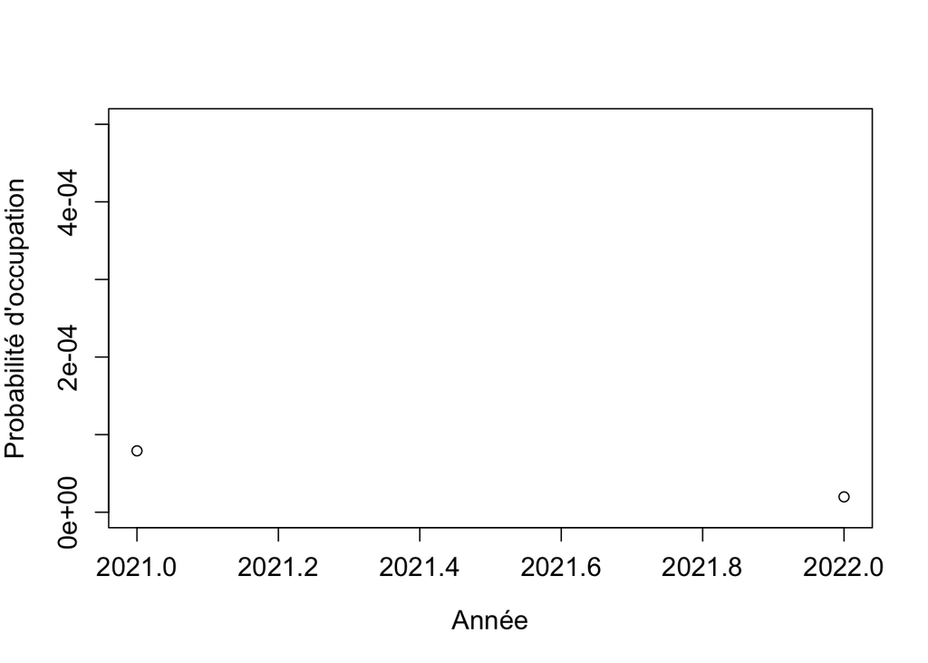

```r
## Data frame où la seule variable qui varie est année
pred.data.an <- data.frame(qualite = factor("bad", levels = levels(anoure$RecordingQuality)),
disturbance = factor("human", levels = levels(anoure$DisturbanceType)),
annee = factor(c("2021", "2022"), levels = levels(anoure$Year)),
jour = 0)

# Tableau des prédictions avec inférence multimodèle
out.preds.an <- modavgPred(cand.set = Cands, modnames = Model.names, newdata = pred.data.an, parm.type = "detect", type = "response")
# Ajout des prédiction au tableau des variables
pred.data.an$fit <- out.preds.an$mod.avg.pred
pred.data.an$se.fit <- out.preds.an$uncond.se
# Ajouts des intervals de confiance au tableau
pred.data.an$low95 <- out.preds.an$lower.CL
pred.data.an$upp95 <- out.preds.an$upper.CL

# Graphique
pred.data.an$xvals <- c("2021", "2022")
plot(fit ~ xvals, data = pred.data.an,  ylim = range(low95, 0.0005), xlab = "Année", ylab = "Probabilité d'occupation", cex.axis = 1.2, cex.lab = 1.2)
```

```r
# Ajout des intervals de confiance
# segments(x0 = pred.data.an$xvals, x1 = pred.data.an$xvals, y0 = pred.data.an$low95, pred.data.an$upp95)
```